# BTS 510 Lab 10

```r
set.seed(12345)
library(tidyverse)
library(Stat2Data)
theme_set(theme_classic(base_size = 16))
```

## 1 Learning objectives

- **Run models** with interaction effects to assess conditional effects of predictors
- **Probe** interaction models to fully understand all effects

## 2 Data

- `ICU` data from the **Stat2Data** package: $n$ = 200
  - `ID`: Patient ID code
  - `Survive`: 1 = patient survived to discharge or 0 = patient died
  - `Age`: Age (in years)
  - `AgeGroup`: 1 = young (under 50), 2 = middle (50-69), 3 = old (70+)
  - `Sex`: 1 = female or 0 = male
  - `Infection`: 1 = infection suspected or 0 = no infection
  - `SysBP`: Systolic blood pressure (in mm of Hg)
  - `Pulse`: Heart rate (beats per minute)
  - `Emergency`: 1 = emergency admission or 0 = elective admission

## 3 Analysis

- Replicate and extend the analysis from the lecture
  - `Age`, `Emergency`, and their interaction predict `Pulse`
  - Be sure to mean center `Age` for interpretability.

## 4 Tasks

- Model 1: `Pulse ~ Age + Emergency`
- Model 2: `Pulse ~ Age + Emergency + Age*Emergency`

```r
library(Stat2Data)
data(ICU)
ICU$AgeC <- ICU$Age - mean(ICU$Age, na.rm = TRUE)
m1 <- lm(data = ICU, Pulse ~ AgeC + Emergency)
m2 <- lm(data = ICU, Pulse ~ AgeC + Emergency + AgeC*Emergency)
```

1. Conduct a likelihood ratio test to compare the models. Report the results. Which model is preferred?

```r
anova(m1, m2, test = "LRT")
```

```
Analysis of Variance Table

Model 1: Pulse ~ AgeC + Emergency
Model 2: Pulse ~ AgeC + Emergency + AgeC * Emergency
  Res.Df    RSS Df Sum of Sq Pr(>Chi)
1    197 138115
2    196 132048  1      6067 0.002692 **
---
Signif. codes:  0 '***' 0.001 '**' 0.01 '*' 0.05 '.' 0.1 ' ' 1
```

```r
logLik(m1)
```

```
'log Lik.' -937.5404 (df=4)
```

```r
logLik(m2)
```

```
'log Lik.' -933.0483 (df=5)
```

```r
-2*(logLik(m1) - logLik(m2))
```

```
'log Lik.' 8.984209 (df=4)
```

- A likelihood ratio tests shows that model 2 with both predictors and their interaction was a better model than model 1 with only both predictors, $\chi^2(1) = 8.98, p<.01$
2. Plot the simple slopes with the data points. What is the general pattern of results?
- Just using **ggplot**

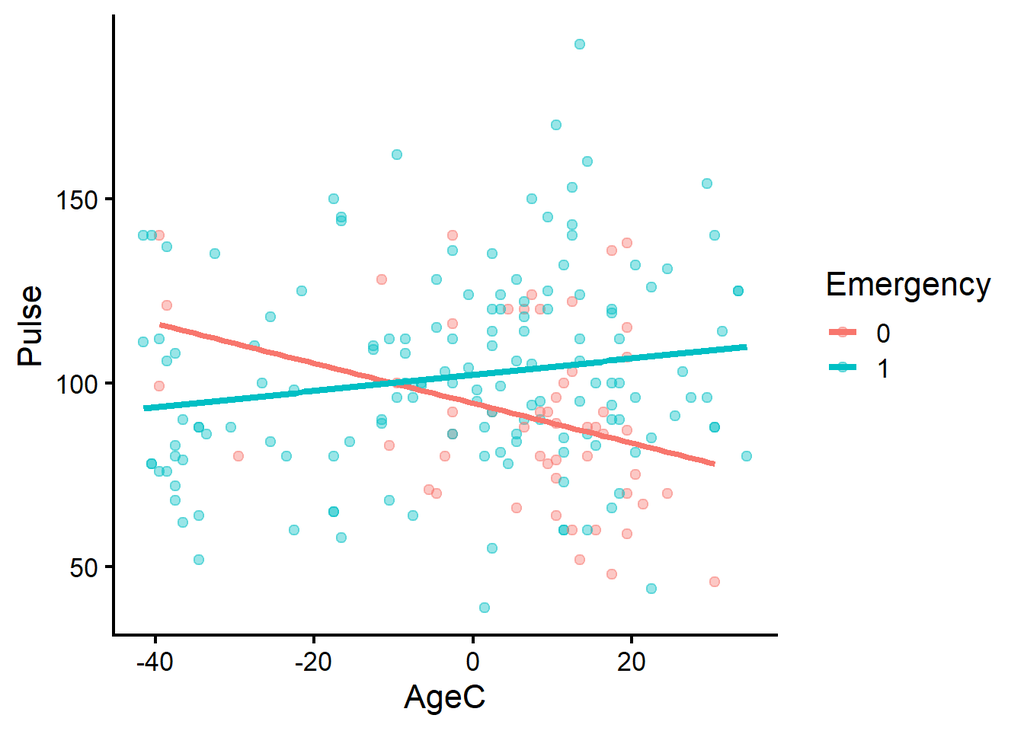

```r
ggplot(data = ICU,
       aes(x = AgeC,
           y = Pulse,
           group = Emergency)) +
  geom_point(aes(color = as.factor(Emergency)),
             alpha = 0.4,
             size = 2) +
  geom_smooth(method = "lm",
              se = FALSE,
              aes(color = as.factor(Emergency))) +
  labs(color = "Emergency")
```

- **interactions** plot

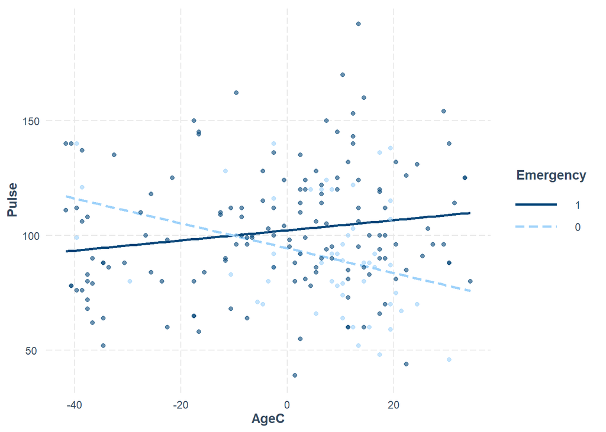

```r
library(interactions)
interact_plot(m2,
              pred = AgeC,
              modx = Emergency,
              plot.points = TRUE)
```

- Broadly: There appears to be a **positive** relationship between age and pulse rate for **emergency** admissions (i.e., older people have higher pulse rates) and a **negative** relationship between age and pulse for **non-emergency** admissions (i.e., older people have lower pulse rates).
3. Conduct simple slopes analysis and the Johnson-Neyman procedure. Report the findings, including test statistics, degrees of freedom, and $p$-values.
- Simple slopes analysis

```r
sim_slopes(m2,
           pred = AgeC,
           modx = Emergency,
           johnson_neyman = FALSE)
```

```
SIMPLE SLOPES ANALYSIS

Slope of AgeC when Emergency = 0.00 (0):

   Est.   S.E.   t val.      p
------- ------ -------- ------
  -0.54   0.23    -2.33   0.02

Slope of AgeC when Emergency = 1.00 (1):

  Est.   S.E.   t val.      p
------ ------ -------- ------
  0.22   0.10     2.16   0.03
```

- For non-emergency admission patients (`Emergency` = 0), the slope for age predicting pulse rate is **significant** and **negative**: $b = -0.54, t(196) = -2.33, p<.05$
- For emergency admission patients (`Emergency` = 1), the slope for age predicting pulse rate is **significant** and **positive**: $b = 0.22, t(196) = 2.16, p<.05$
- Johnson-Neyman procedure
  - Probably not the direction you want to talk about effects

```
JOHNSON-NEYMAN INTERVAL

When Emergency is OUTSIDE the interval [0.26, 0.97], the slope of AgeC is p
< .05.

Note: The range of observed values of Emergency is [0.00, 1.00]
```

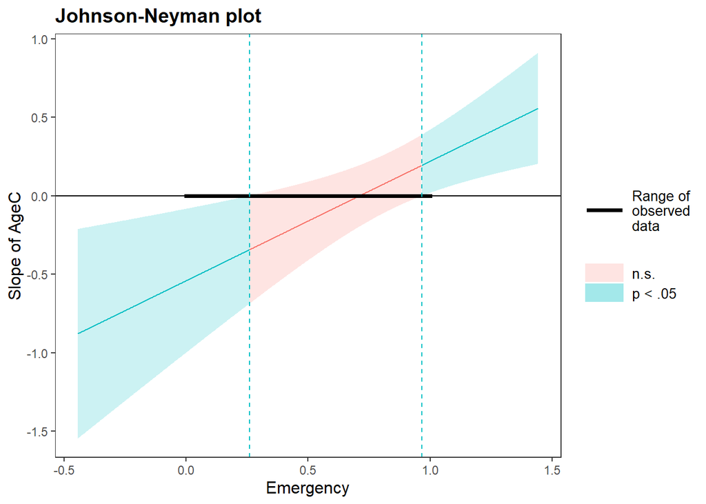

```r
johnson_neyman(m2,
               pred = AgeC,
               modx = Emergency,
               alpha = .05)
```

- The slope for age predicting pulse rate is **significant** and **positive** for emergency admission patients (`Emergency` = 1)
  - Blue section in upper right of plot
- The slope for age predicting pulse rate is **significant** and **negative** for non-emergency admission patients (`Emergency` = 0)
  - Blue section in lower left of plot
- Johnson-Neyman procedure
  - Usually talk about effects in this direction

```
JOHNSON-NEYMAN INTERVAL

When AgeC is OUTSIDE the interval [-44.31, 1.06], the slope of Emergency is
p < .05.

Note: The range of observed values of AgeC is [-41.55, 34.45]
```

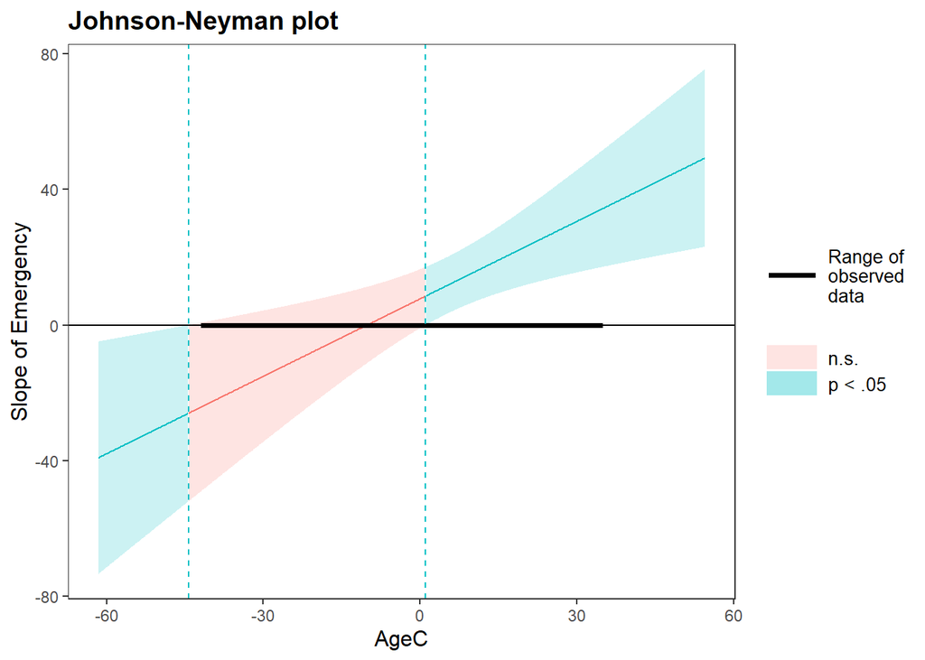

```r
johnson_neyman(m2,
               pred = Emergency,
               modx = AgeC,
               alpha = .05)
```

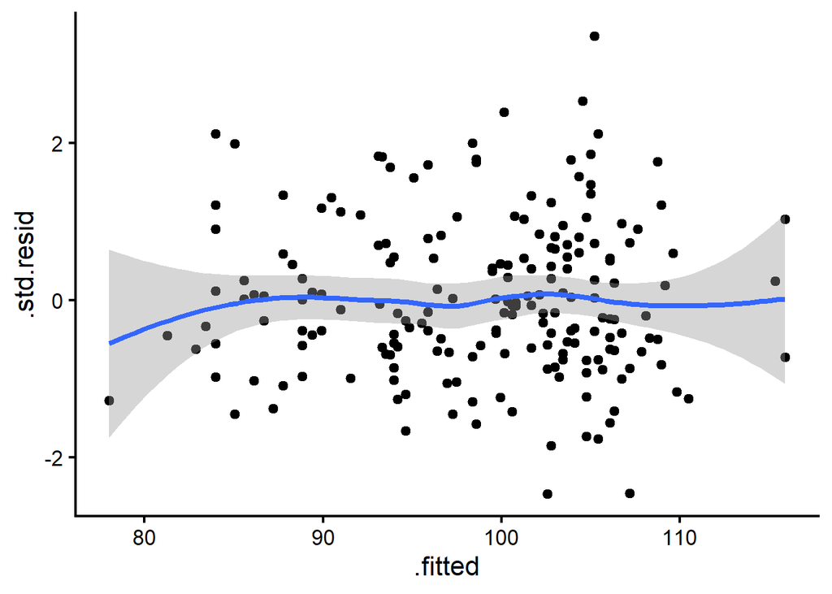

```r
library(broom)
ICU_aug <- augment(m2)
ICU_aug <- ICU_aug %>% mutate(new_ID = 1:nrow(ICU_aug))

ggplot(data = ICU_aug,
       aes(x = .fitted,
           y = .std.resid)) +
  geom_point() +
  geom_smooth()
```

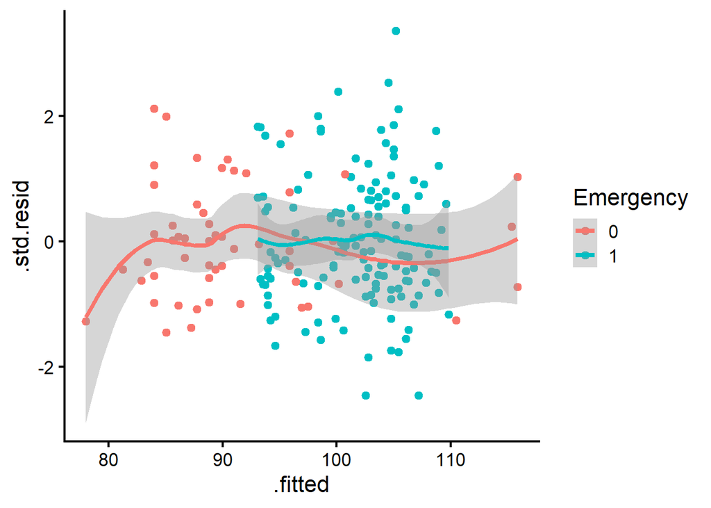

```r
ggplot(data = ICU_aug,
       aes(x = .fitted,
           y = .std.resid,
           color = as.factor(Emergency))) +
  geom_point() +
  geom_smooth() +
  labs(color = "Emergency")
```

- Leverage

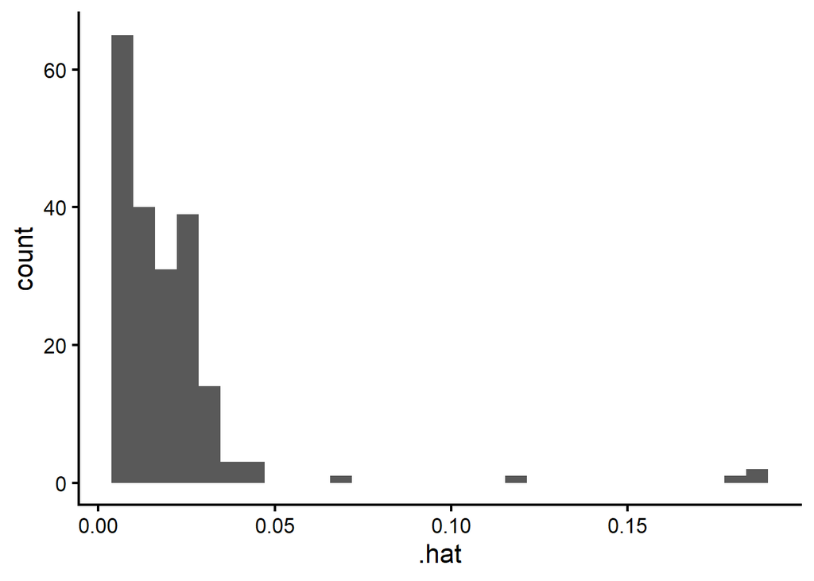

```r
ggplot(data = ICU_aug,
       aes(x = .hat)) +
  geom_histogram()
```

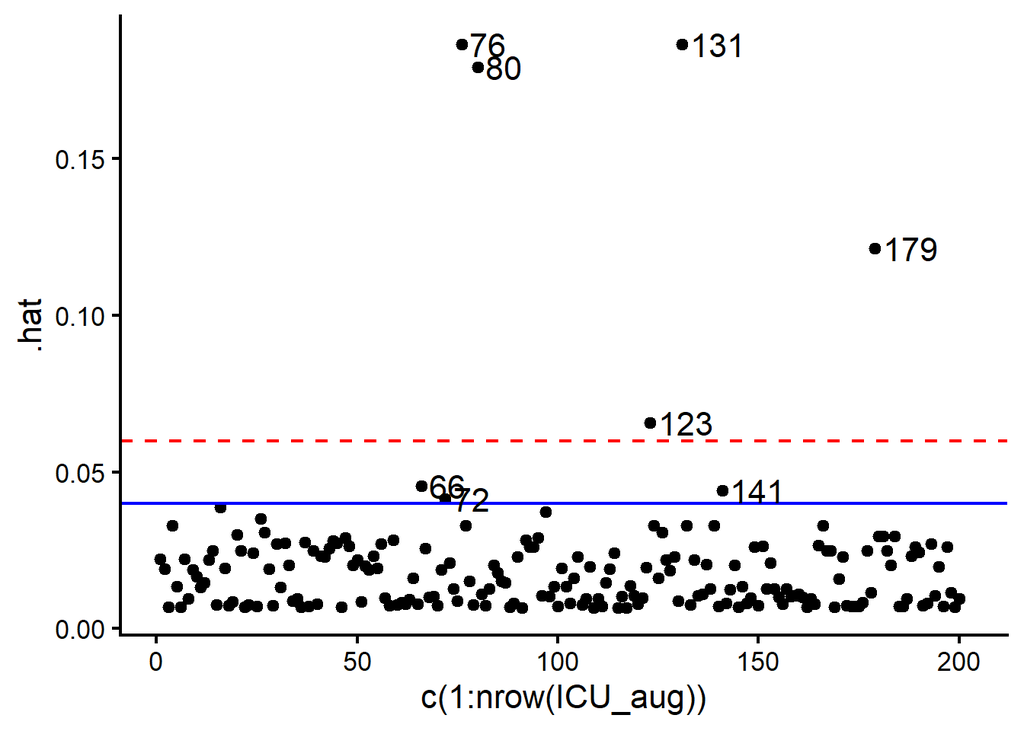

```r
ggplot(data = ICU_aug,
       aes(x = c(1:nrow(ICU_aug)),
           y = .hat)) +
  geom_point() +
  geom_hline(yintercept = 3*(3+1)/200,
             color = "red",
             linetype = "dashed") +
  geom_hline(yintercept = 2*(3+1)/200,
             color = "blue") +
  geom_text(aes(label=ifelse((.hat > 2*(3+1)/200),
                             as.character(new_ID),
                             '')),
            hjust = 0, nudge_x = 2)
```

- Discrepancy

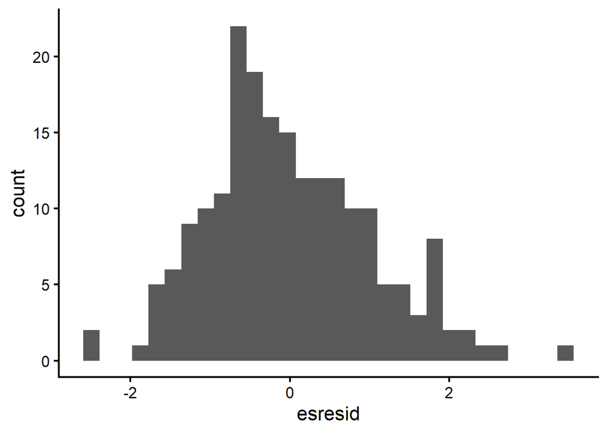

```r
ICU_aug <- ICU_aug %>% mutate(esresid = rstudent(m2))

ggplot(data = ICU_aug,
       aes(x = esresid)) +
  geom_histogram()
```

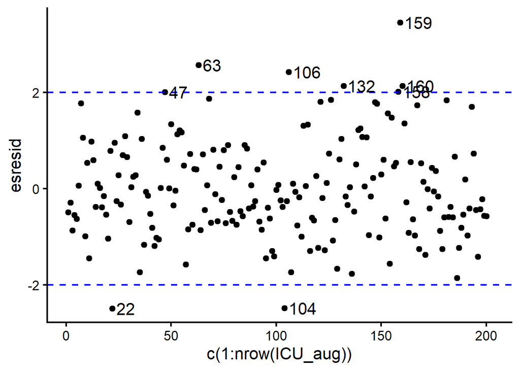

```r
ggplot(data = ICU_aug,
       aes(x = c(1:nrow(ICU_aug)),
           y = esresid)) +
  geom_point() +
  geom_hline(yintercept = 2,
             color = "blue",
             linetype = "dashed") +
  geom_hline(yintercept = -2,
             color = "blue",
             linetype = "dashed") +
  geom_text(aes(label=ifelse((esresid > 2),
                             as.character(new_ID),
                             '')),
            hjust = 0, nudge_x = 2) +
  geom_text(aes(label=ifelse((esresid < -2),
                             as.character(new_ID),
                             '')),
            hjust = 0, nudge_x = 2)
```

- Influence

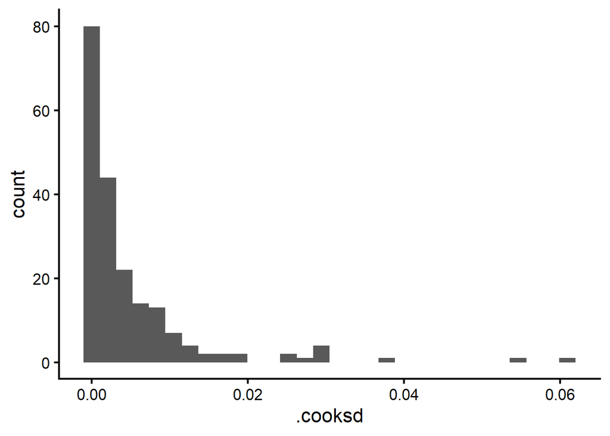

```r
ggplot(data = ICU_aug,
       aes(x = .cooksd)) +
  geom_histogram()
```

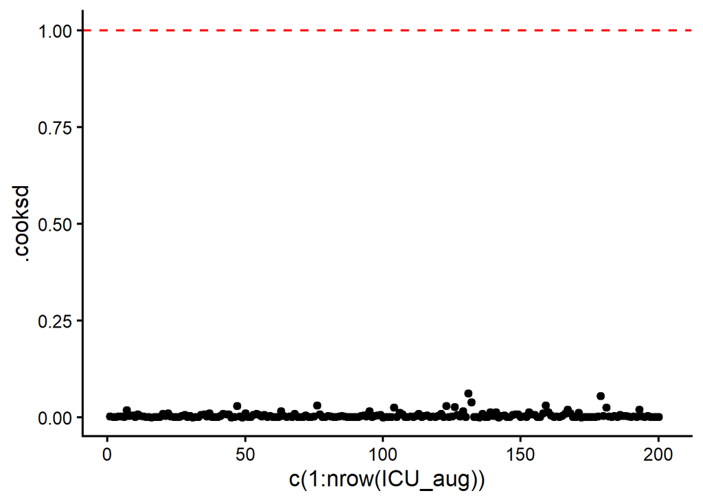

```r
ggplot(data = ICU_aug,
       aes(x = c(1:nrow(ICU_aug)),
           y = .cooksd)) +
  geom_point() +
  geom_hline(yintercept = 1,
             color = "red",
             linetype = "dashed") +
  geom_text(aes(label=ifelse((.cooksd > 1),
                             as.character(new_ID),
                             '')),
            hjust = 0, nudge_x = 2)
```

- Repeat offenders
- Leverage

```r
ICU_aug %>% filter(.hat > 2*(3+1)/200) %>% select(new_ID)
```

```
# A tibble: 8 × 1
  new_ID
   <int>
1     66
2     72
3     76
4     80
5    123
6    131
7    141
8    179
```

- Discrepancy

```r
ICU_aug %>% filter(esresid > 2) %>% select(new_ID)
```

```
# A tibble: 7 × 1
  new_ID
   <int>
1     47
2     63
3    106
4    132
5    158
6    159
7    160
```

```r
ICU_aug %>% filter(esresid < -2) %>% select(new_ID)
```

```
# A tibble: 2 × 1
  new_ID
   <int>
1     22
2    104
```

- Influence

```r
ICU_aug %>% filter(.cooksd > 1) %>% select(new_ID)
```

```
# A tibble: 0 × 1
# ℹ 1 variable: new_ID <int>
```

- There were no observations that showed up as outliers across multiple metrics
- No observations had high influence, so no observations were outliers that were changing results
5. Describe the overall findings for this model, including the analyses to probe the interaction. Be statistically accurate but avoid jargon and technical terms as much as you can. Be sure to use the names of the variables studied (i.e., pulse, age, emergency admission) rather than X and Y.
- When there is a significant interaction, all lower order effects are **conditional**
  - You can’t talk about **just** the effect of age – it’s conditional on admission type
  - You can’t talk about **just** the effect of admission type – it’s conditional on age
- The **effect of age on pulse rate** depended on admission type
  - Older emergency admission patients had higher pulse rate than younger emergency admission patients, but the opposite was observed for non-emergency admission patients: Older non-emergency admission patients had lower pulse rate than younger non-emergency admission patients
- The **effect of admission type on pulse rate** depended on age
  - Emergency admission patients had higher pulse rate than non-emergency admission patients, but only for patients who were at least 58.6 year old